# Sociología del Género

SOL3061 | Clase 6. Trabajo y familia

Tania Hutt

## Hilo de la clase

#### Trabajo no remunerado

Familia, división del trabajo y carga mental.

→

#### Expectativas del empleador

Selección, estereotipos y castigo a la maternidad.

→

#### Salarios

Brecha salarial y segregación.

# Familia

## ¿Qué es la familia?

(Cohen, *The Family: Diversity, Inequality, and Social Change*)

**Personal**

Quiénes considero mi familia.

**Legal**

La que reconoce el Estado.

**Institucional**

Normas y prácticas que organizan reproducción, cuidado y recursos.

- Estudiar juntas la **diversidad** de familias y la **desigualdad** que las atraviesa.

## La familia como institución generizada

- La familia y el trabajo remunerado como **instituciones avaras**: compiten por el mismo tiempo y lealtad.
- **Maternidad intensiva**: la crianza debe ser absorbente, centrada en los hijos y realizada por las madres.
- En América Latina, las políticas **maternalistas** asignan el cuidado a las madres.

## ¿Por qué persiste la división desigual?

- **Especialización:** el hogar es más eficiente si cada uno se especializa.
- **Tiempo y recursos relativos:** quien gana más o trabaja más horas negocia hacer menos.
- **Hacer género:** el trabajo doméstico también es una forma de **demostrar** el género.

Si fuera solo intercambio económico, ¿por qué los hombres que dependen económicamente de sus parejas no hacen más trabajo doméstico?

## La “revolución estancada”

- **Tradicionalista**, **neo-tradicionalista**, **igualitaria**: las **actitudes** se volvieron más igualitarias que las **prácticas**.
- Cambio **asimétrico**: las mujeres entraron al trabajo remunerado, pero los hombres no entraron en la misma medida al cuidado.
- La desigualdad se desplaza a lo menos visible: la **carga mental**.

## Estereotipos de ma-paternidad

- Los estereotipos y representaciones en medios sobre la ma-paternidad son *gendered*: la madre 100% dedicada y experta, el padre incompetente e inútil.
- Se ven en medios, películas, redes sociales, etc.

[Video 1](https://www.youtube.com/watch?v=jHPbOGEUvZA) · [Video 2](https://www.youtube.com/watch?v=jyMZ_LOVcvo)

# Trabajo remunerado

## Género y clase en un mercado laboral de élite

(Rivera & Tilcsik 2016)

- Estudio de correspondencia en estudios de abogados.
- Postulantes recién graduados de la universidad.
- Manipulación experimental de **género** (nombre) y **clase** (señales en el currículum):

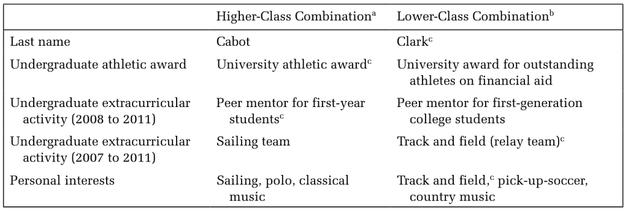

## Principales resultados

- Los hombres de clase alta reciben una tasa de respuesta **cuatro veces mayor** que el promedio de los demás postulantes.
- La clase alta aumenta la probabilidad de entrevista, **pero solo para los hombres**.
- En la encuesta experimental, los hombres de clase alta **no** son evaluados como más competentes ni más cálidos: se descartan esos dos mecanismos.

## Las mujeres de clase alta: “poco compromiso”

- Las mujeres de clase alta son evaluadas como **menos comprometidas** con la carrera que los hombres de clase alta y que las mujeres de clase más baja.
- Las señales de clase alta se asocian con mejor **“fit”** cultural con la empresa, que aumenta la recomendación de entrevista.
- Mujeres de clase baja: buena ética de trabajo pero **mal fit**.
- Mujeres de clase alta: fuertes académica y profesionalmente, pero con **bajo compromiso**: se teme que no duren porque tendrán el privilegio económico de no hacerlo.

## Cómo se contrata en Chile

(Undurraga 2019)

- **43 entrevistas** con gerentes, consultores de recursos humanos y postulantes en Santiago; seis etapas del proceso de selección.
- El “fit” se filtra por **idiomas, colegio, universidad, comuna** y apellido.
- Se pregunta por estado civil, pareja e hijos; se usan **tests proyectivos** (p. ej., Rorschach) sin evidencia de validez.
- Discurso de **meritocracia** que esconde **discriminación explícita**.

## Dos formas de mirar la contratación

**Rivera y Tilcsik (2016)**

Experimento de correspondencia: **causal**, aísla el efecto de género y clase en la invitación a entrevista. Dice *qué* pasa, pero no *cómo*.

**Undurraga (2019)**

Entrevistas: **mecanismos** y discurso de quienes contratan. Dice *cómo* se justifica, pero no mide el efecto.

Si el “fit” es el mecanismo, ¿qué diría un reclutador chileno sobre una candidata de clase alta que “no se compromete”?

# Trabajo doméstico y carga mental

## Carga mental

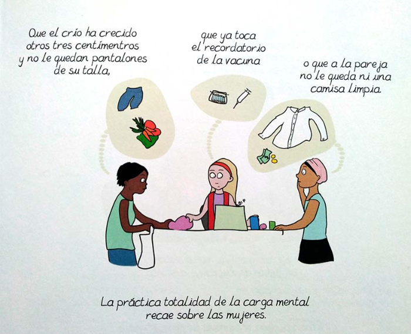

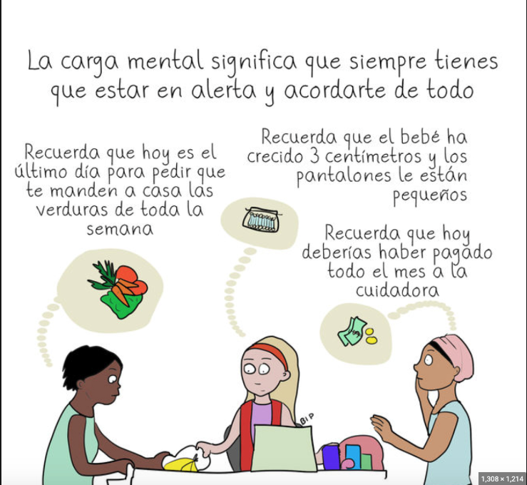

## La dimensión cognitiva del trabajo doméstico

(Daminger 2019)

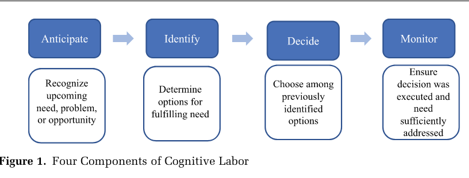

- **Invisible** para otras personas, y a veces para quien lo hace.
- Difuso: cuesta registrarlo y cuantificarlo.

## Diferencias de género en el trabajo cognitivo

(Daminger 2019)

- Las mujeres hacen **más trabajo cognitivo** en general, y más de la **anticipación** y el **monitoreo**.
- La participación en la **decisión** es aproximadamente igual.
- Fuente frecuente de **conflicto** en las parejas.

# Maternidad y mercado laboral

## Castigo a la maternidad en salarios en Latinoamérica

(Villanueva & Lin 2019)

- Castigo a la maternidad en cinco países: desde **12% en Brasil** a **21% en Chile** (el más alto).
- La participación de las madres en el **trabajo informal** explica parte del castigo.
  - Pero **no en Chile**: la maternidad no es un determinante tan importante del trabajo informal como en otros países.

## Qué explica (y qué no) el castigo en Chile

(Villanueva & Lin 2019)

- Chile tiene la penalización **más alta** y es el **único** país donde la informalidad no la explica.
- Los autores lo atribuyen a la **baja participación femenina** y a un sector informal pequeño.
- ¿Es el 21% una penalización de las madres, o de las pocas madres que **permanecen** trabajando?

## Castigo a la maternidad en contrataciones en EE.UU.

(Correll et al. 2007; Ishizuka 2021)

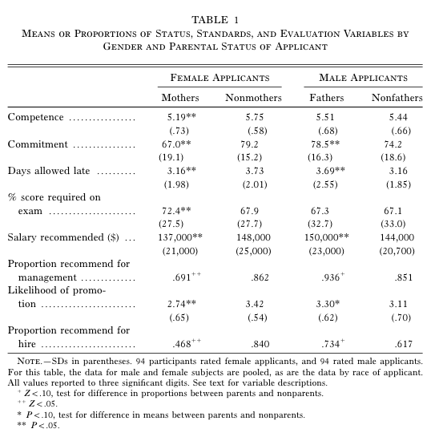

## Sesgos asociados a la maternidad (EE.UU.)

- El foco tiende a estar en la **maternidad**, con impactos en participación laboral, salarios y oportunidades.
- ¿Se extiende la penalización a mujeres que **no son madres**?
- Las mujeres podrían ser afectadas solo por la **expectativa** de que serán madres en el futuro.

## Maternidad actual y potencial en Chile: el estudio

(Cabello-Hutt, en proceso; resultados preliminares)

- Experimento factorial con **1.449 supervisores/as** en Chile que evalúan perfiles ficticios de postulantes a una vacante.
- Los perfiles varían **género**, estado civil, **situación parental** (0, 1 o 2 hijos/as), **planes familiares** (en 2 años, en 5 años, no desea), experiencia y desempeño.
- Resultados: **evaluación** (contratación), **competencia**, **crecimiento**, **costo** y **riesgo**.
- Contexto **maternalista**: licencia extensa para madres, casi sin licencia de paternidad y sala cuna ligada a las trabajadoras.

## Resultado: recomendación de contratación

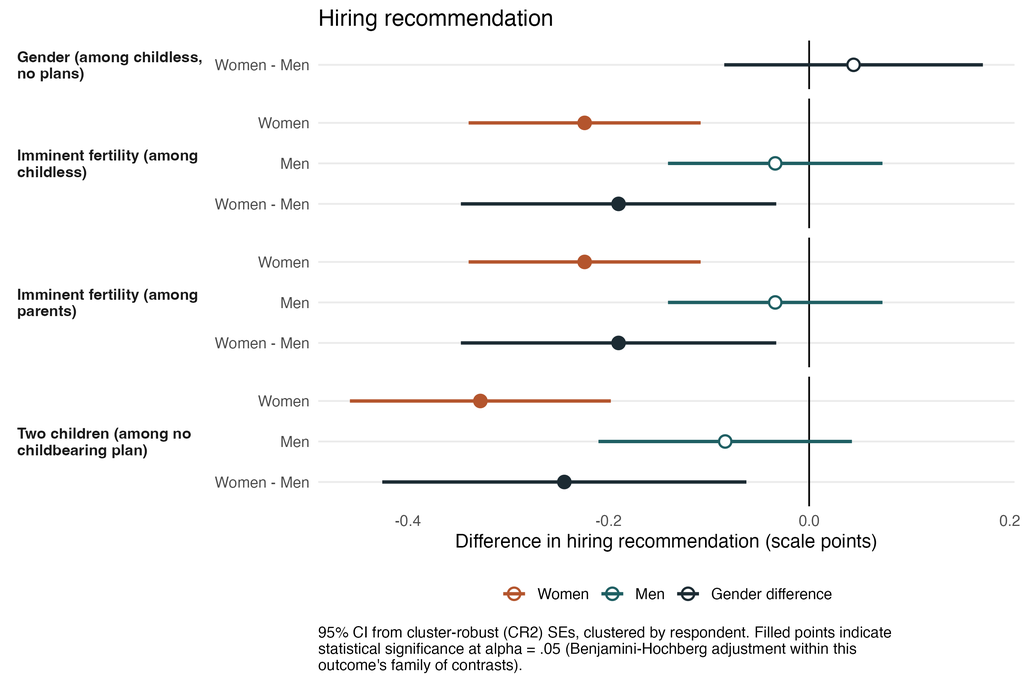

## Resultado: índice de riesgo

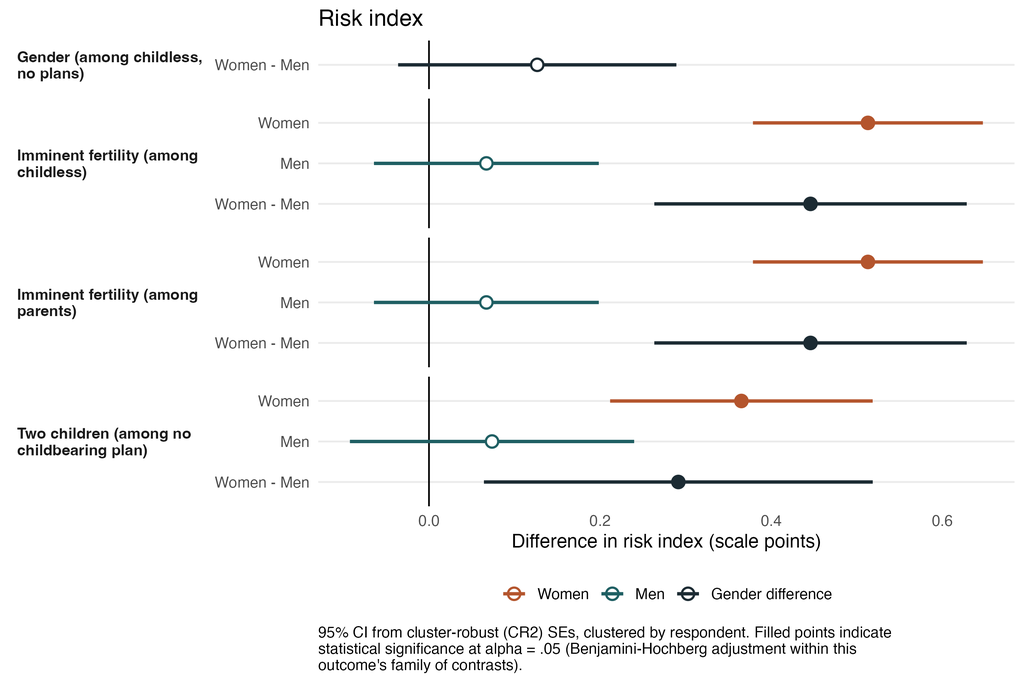

## Resumen de resultados preliminares

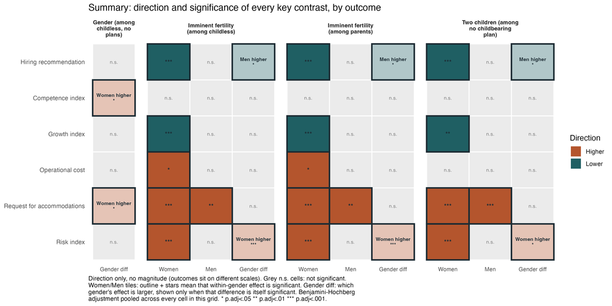

## La asimetría clave

- Las señales familiares aumentan el uso esperado de **facilidades** para mujeres **y** hombres.
- Pero las consecuencias negativas (costo, menor crecimiento, riesgo) recaen **solo sobre las mujeres**.
- En Chile, las políticas vinculan licencias y beneficios **primordialmente a las madres**.

Si la competencia no es penalizada, ¿es más efectivo cambiar percepciones o cambiar las políticas?

# Brecha salarial

## Brecha salarial en Chile

(Cruz & Rau 2022)

- Datos administrativos: brecha salarial de **24%**, pero heterogénea.
- Por tamaño de empresa: hasta 10 trabajadores, **8%**; 200 o más, **36%**.
- Por sector: financiero, **9%**; minería, **48%**.
- **82–92%** de la brecha se debe a que las mujeres están subrepresentadas en empresas que pagan salarios altos y sobrerrepresentadas en las que pagan bajos.
- **8–18%** se debe a diferencias entre hombres y mujeres con igual educación y habilidad en las mismas empresas.

Si la mayor parte de la brecha es **segregación entre empresas**, ¿es discriminación o “elección”? ¿Quién decide a qué empresas llegan las mujeres?